## Maxime GEAY - Dominique JEANCLER - Julien MAKSOUD - Chloé RICHARD

## MS BGD 2020-2021

## SD701 - BIG DATA MINING

# Analyse en Graphes du Réseau de Transport Francilien

```python
import json
import csv
import networkx as nx
import os, sys,glob
import pandas as pd
import numpy as np
import sknetwork as skn
import collections
import matplotlib.pyplot as plt
from fa2 import ForceAtlas2
import random
import ipyleaflet
from random import randint
from lxml import etree
import matplotlib.pyplot as plt
import re
import seaborn as sns
# import warnings
# warnings.filterwarnings('ignore')
# options d'affichage
pd.set_option("display.min_rows", 16)

from IPython.display import SVG
from sknetwork.topology import connected_components,CoreDecomposition
from sknetwork.utils.format import bipartite2undirected,directed2undirected
from sknetwork.utils import edgelist2adjacency,edgelist2biadjacency, membership_matrix
from sknetwork.data import load_edge_list, load_graphml, load_netset, load_konect
from sknetwork.ranking import Katz, BiKatz
from sknetwork.clustering import Louvain, BiLouvain, modularity, bimodularity
from sknetwork.linalg import normalize
from sknetwork.clustering import PropagationClustering, BiPropagationClustering, modularity, bimodularity
from sknetwork.visualization import svg_graph, svg_digraph, svg_bigraph, svg_dendrogram
from sknetwork.hierarchy import Paris,cut_straight, dasgupta_score, tree_sampling_divergence
from sknetwork.ranking import PageRank
from sknetwork.path import distance,shortest_path

import matplotlib.pylab as pylab
params = {'legend.fontsize': 'x-large',
          'figure.figsize': (15, 8),
         'axes.labelsize': 'x-large',
         'axes.titlesize':'x-large',
         'xtick.labelsize':'x-large',
         'ytick.labelsize':'x-large'}
pylab.rcParams.update(params)

#Import pour exploitation des graph

#Import outil pour visualisation de carte
from ipyleaflet import Map, AntPath,CircleMarker
from ipyleaflet import Map,basemaps, basemap_to_tiles
from ipyleaflet import LayersControl,FullScreenControl,ScaleControl
from geopy.geocoders import Nominatim
```

# Imports et Définitions de Paths

```python
nodefile = "vertex/vertex.csv"
edgefile = "edge/edge.csv"
jsonfile = "geojson/multigraph.geojson"
graphmlfile = "graphml/multigraph.graphml"
gmlfile = "gml/multigraph.gml"

if not os.path.exists("edge"):
    os.makedirs("edge")
if not os.path.exists("vertex"):
    os.makedirs("vertex")
if not os.path.exists("gml"):
    os.makedirs("gml")
```

```python
nodes = pd.read_csv(nodefile)
nodes.columns = ["NodeID","Long","Lat","Layer"]
nodes_train = nodes[nodes["Layer"]=='train']
nodes_road = nodes[nodes["Layer"]=='road']
nodes_metro = nodes[nodes["Layer"]=='metro']
nodes_tram = nodes[nodes["Layer"]=='tram']
nodes["Layer"].unique()
nodes_transports_commun = nodes[nodes["Layer"] !='road']
```

```python
## PREND 3 MINUTES A TOURNER SI DECOMMENTE

edges = pd.read_csv(edgefile)
edges = edges.reset_index()
edges.columns = ["edgeID","SourceNodeID","TargetNodeID","Direction","Layer","Name"]

# tmp1 = []
# tmp2 = []
# tmp3 = []
# tmp4 = []

# for i in edges.index:
#     tmp1.append(float(str(nodes[nodes["NodeID"]==edges["SourceNodeID"][i]]["Lat"]).split()[1]))
#     tmp2.append(float(str(nodes[nodes["NodeID"]==edges["SourceNodeID"][i]]["Long"]).split()[1]))
#     tmp3.append(float(str(nodes[nodes["NodeID"]==edges["TargetNodeID"][i]]["Lat"]).split()[1]))
#     tmp4.append(float(str(nodes[nodes["NodeID"]==edges["TargetNodeID"][i]]["Long"]).split()[1]))

# edges["Source_Lat"] = tmp1
# edges["Source_Lon"] = tmp2
# edges["Target_Lat"] = tmp3
# edges["Target_Lon"] = tmp4

# edges["Length"] = ((edges["Target_Lat"]-edges["Source_Lat"])**2 + (edges["Target_Lon"]-edges["Source_Lon"])**2)**0.5

# edges
```

```python
edges_road = edges[edges["Layer"]=='road']
edges_tram = edges[edges["Layer"]=='tram']
edges_train = edges[edges["Layer"]=='train']
edges_transports_commun = edges[(edges["Layer"] == 'tram') | (edges["Layer"] == 'metro') | (edges["Layer"] == 'train')]
edges_metro = edges[edges["Layer"]=='metro']
```

# Représentation en graph pour le métro

### Génération du graph et export en fichier graphml

Comme nx ne nous donnait que peu de metrics intéressants (jusqu'à ce qu'on découvre comment faire...), nous avons créé un graph à partir d'une série de points avec nx.Graph ou nx.Digraph. Puis avons généré des fichiers graphml qui sont lisibles par sknetwork.

```python
## AJOUT DES NOEUDS ET EDGES AU GRAPH
Gmetro = nx.DiGraph()  # on créé un graph directionnel

for row in range(len(nodes_metro)):
    IDnode = nodes_metro.iloc[row,0]
    latnode = nodes_metro.iloc[row,1]
    longnode = nodes_metro.iloc[row,2]
    typenode = nodes_metro.iloc[row,3]
    Gmetro.add_node(IDnode, lat=latnode, lon=longnode, type=typenode)

for row in range(len(edges_metro)):
    origedge = edges_metro.iloc[row,1]
    destedge = edges_metro.iloc[row,2]
    typeedge = edges_metro.iloc[row,4]
    nameedge = edges_metro.iloc[row,5]
    lengthedge = edges_metro.iloc[row,-1]
#     print(origedge,destedge,typeedge,nameedge)
    Gmetro.add_edge(origedge,destedge,type=typeedge,name=nameedge,length=lengthedge)
    # gestion du cas du graph directionnel: Si c'est un twoway, il faut ajouter l'edge qui va en sens inverse
    if edges_metro.iloc[row,3]=='TwoWay':
        Gmetro.add_edge(destedge,origedge,type=typeedge,name=nameedge,length=lengthedge)


#  EXPORT EN GRAPHMLFILE
nx.write_graphml(Gmetro, graphmlfile)
nx.write_graphml(Gmetro, gmlfile)
```

```python
# Chargement du fichier généré au dessus
graph = load_graphml('graphml/multigraph.graphml')
adjacency = graph.adjacency  # calcul d'adjacency
names = graph.names  # extraction des noms

# position: Comme position doit être une liste de tuples et que lat-lon n'est pas bien organisé, il faut
# lire dans le fichier graph et regénérer le tuple pour être sknetwork-compatible.
lon = list(graph['node_attribute']['lon'].astype(float))
lat = list(graph['node_attribute']['lat'].astype(float))
position = np.array([list(x) for x in zip(lat, lon)])

# labels=graph.edge_attribute
labels = connected_components(adjacency)

# Creation et display du graph
image = svg_graph(adjacency,position=position, labels=labels,width=1000,height=1000,node_size=6)
SVG(image)
```

[figure not shown]

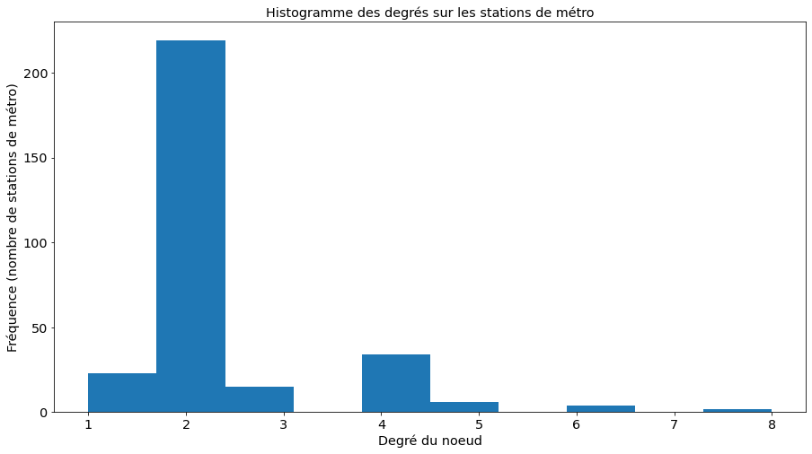

```python
degrees = np.array(adjacency.dot(np.ones(adjacency.shape[0])))
degrees = [val/2 for (node,val) in Gmetro.degree()]
plt.xlabel('Degré du noeud')
plt.ylabel('Fréquence (nombre de stations de métro)')
plt.title('Histogramme des degrés sur les stations de métro')
plt.hist(sorted(degrees))
```

# Centralité du Graph

```python
# https://en.wikipedia.org/wiki/Katz_centrality
katz = Katz(damping_factor=0.5)
scores = katz.fit_transform(adjacency)
image = svg_graph(adjacency, position, scores=scores,node_size=7,height=1000,width=1000)
SVG(image)
```

[figure not shown]

La formule et la définition de la centralité de Katz est donnée ci-dessous (Wikipédia)

$$ C_{Katz}(i) = \sum_{k=1}^{\infty}\sum_{j=1}^{n}\alpha^k(A^k)_{ji}$$

Avec les paramètres par défaut, on repère sans difficulté la centralité de Chatelet et République. Dans une moindre mesure, Bastille, Gare de l'Est, Stalingrad et une polarisation dans le quartier de Saint Lazare

On voit que la centralité est calculée à l'aide du second voisin. On constate la centralité de République et Châtelet quelque soit le paramètre alpha. Quand alpha tend vers 0 (par exemple alpha = 0.1, Saint Lazare reste centrale mais de manière moins prononcée.

On peut donc dire que Chatelet et République sont "centrales" du fait de leurs nombreux premiers voisins. Ce sont les stations qui ont le plus de connections.

Par contre, la centralité de Katz observée dans le quartier de Saint-Lazare semble être liée au fait de nombreuses connections réparties sur différentes stations.

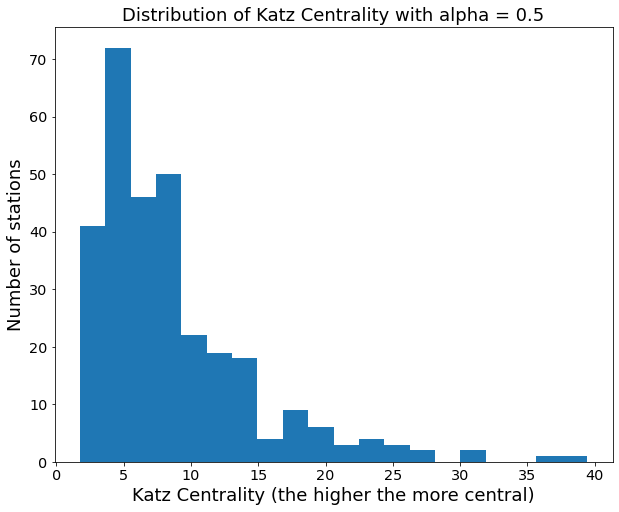

```python
katz = Katz(damping_factor=0.5)
scores = katz.fit_transform(adjacency)
plt.figure(figsize=(10,8))
plt.hist(sorted(scores),bins=20)
plt.ylabel('Number of stations',size=18)
plt.xlabel('Katz Centrality (the higher the more central)',size=18)
plt.title('Distribution of Katz Centrality with alpha = 0.5',size=18)
```

# CLUSTERING

### LOUVAIN

```python
## REGARDER DETAILS TECHNIQUES - CLUSTER PAR ZONE GEOGRAPHIQUE
louvain = Louvain(resolution= 1,
                  modularity= 'dugue',  # peut etre dugue, newman, potts mais ça revient exactement au même
                  tol_optimization = 0.001,
                  tol_aggregation = 0.00001,
                  n_aggregations = -1,
                  shuffle_nodes = False,
                  sort_clusters = True,
                  return_membership = True,
                  return_aggregate = True,
                  random_state = None,
                  verbose = False)
# louvain = Louvain(modularity='potts')
labels = louvain.fit_transform(adjacency)
labels_unique, counts = np.unique(labels, return_counts=True)
image = svg_graph(adjacency, position, labels=labels,node_size=6,height=500,width=500)
SVG(image)
# https://scikit-network.readthedocs.io/en/latest/reference/clustering.html?highlight=louvain#sknetwork.clustering.Louvain
```

[figure not shown]

```python
# METRICS
print('La modularité de ce graph de Louvain est de : ' , round(modularity(adjacency, labels),3))
```

```
La modularité de ce graph de Louvain est de :  0.799
```

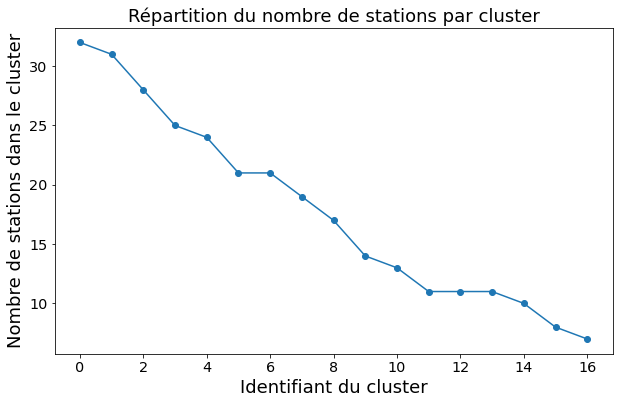

```
Le clustering est inégal car génère des clusters de tailles très différentes
```

```python
plt.figure(figsize=(10,6))
plt.plot(labels_unique,counts,linestyle='-', marker='o')
plt.xlabel('Identifiant du cluster',size=18)
plt.ylabel('Nombre de stations dans le cluster',size=18)
plt.title('Répartition du nombre de stations par cluster',size=18)
plt.show()
print('Le clustering est inégal car génère des clusters de tailles très différentes')
```

### LOUVAIN AGGREGATE GRAPH (permet de voir si zones géographiques définies)

```python
adjacency_aggregate = louvain.adjacency_
average = normalize(membership_matrix(labels).T)
position_aggregate = average.dot(position)
labels_unique, counts = np.unique(labels, return_counts=True)
image = svg_graph(adjacency_aggregate, position_aggregate, counts, labels=labels_unique,
                  display_node_weight=True, node_weights=counts, scale=0.5,node_size=4,height=700,width=700)
SVG(image)
```

[figure not shown]

Après avoir vu l'utilisation de l'algorythme de Louvain et sa forme aggrégée pour avoir une vue à large échelle des régions et de leurs connexions, nous utilisons maintenant un outil de classification hierarchique.

Cet outil va créer des clusters de manière itératives en aggrégeant les noeuds ayant le maximum de similarité. Dans notre contexte (x,y comme attribut des noeuds), on va regrouper les noeuds les plus proches. Les résultats nous semble pertinents pour des problématiques portant sur la gestion de services matériels partagés comme par exemple:

- Disposition de générateur de courant de secours ne pouvant alimenter que n stations
- Localisatino d'équipe d'intervention en proximité (temps d'intervention en temps minimum etc etc)

Dans notre cas nous avons simulé une classification hiérarchique prenant en compte deux conditions à savoir un maximum de 60 stations par cluster (soit un cinquième de notre réseau) et un ratio de max 2 entre nombre maximum et minimum de station par cluster.

En observant le dendograme, on retrouve bien que l'algorythme regroupe en dernier lieux les zones périphériques ayant la plus faible densité de couverture.

```python
paris = Paris()
dendrogram = paris.fit_transform(adjacency)
labels = cut_straight(dendrogram)
n_clusters = 2
max_count=nodes_metro["NodeID"].nunique()
min_count=1
while ((max_count > 60) and (max_count/min_count > 2)):
    n_clusters = n_clusters +1
    labels, dendrogram_aggregate = cut_straight(dendrogram, n_clusters, return_dendrogram=True)
    famille, counts = np.unique(labels, return_counts=True)
    max_count = max(counts)
    min_count= min(counts)
count_famille=[(i,counts[i]) for i in range(n_clusters)]
image = svg_dendrogram(dendrogram_aggregate, names=famille, rotate_names=False,color='gray',height=90)
print (f"On a réparti le réseau en {n_clusters} avec le nombre de stations suivante par nom de cluster {count_famille}",sep=' ')
print ('Ce qui nous donne le dendogramme suivant :')
SVG(image)
```

```
On a réparti le réseau en 9 avec le nombre de stations suivante par nom de cluster [(0, 45), (1, 41), (2, 39), (3, 38), (4, 35), (5, 30), (6, 28), (7, 24), (8, 23)]
Ce qui nous donne le dendogramme suivant :
```

[figure not shown]

```python
image = svg_graph(adjacency, position,labels=labels,width=800,height=800,names=labels,font_size=8)
SVG(image)
```

[figure not shown]

# PAGERANK

```python
#option nodeweight =TRUE pour afficher taille noeud en fonction du pagerank
from sknetwork.ranking import PageRank, BiPageRank
from sknetwork.visualization import svg_graph, svg_digraph, svg_bigraph
adjacency = graph.adjacency
pagerank = PageRank()
scores = pagerank.fit_transform(adjacency)
image = svg_graph(adjacency, position, scores=np.log(scores), display_node_weight=True,width=1000,height=1000)
SVG(image)
```

[figure not shown]

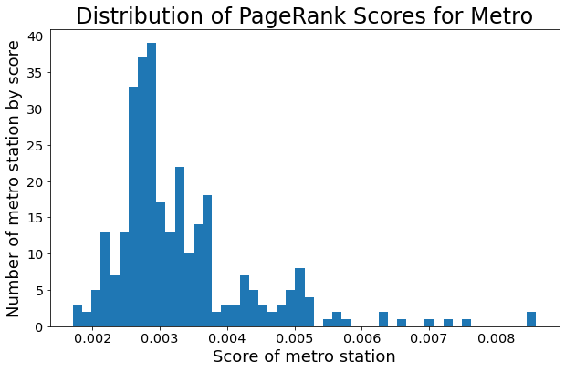

```python
plt.figure(figsize=(10,6))
plt.hist(sorted(scores),bins=50)
plt.xlabel('Score of metro station',size=18)
plt.ylabel('Number of metro station by score',size=18)
plt.title('Distribution of PageRank Scores for Metro',size=24)
```

##### On récupère les 10 stations au PageRank score les plus élevé et on en créé un dictionnaire.

L'idée est de voir si les "hubs" sont bien répartis sur le réseau de métro. On observe que scores les plus faibles correspondent aux bouts de lignes (terminus et stations avoisinantes)

```python
nn = 10
scoresdf =pd.Series(scores)
scoresdf = scoresdf.sort_values(ascending=False)
TenSeeds = scoresdf.index[0:nn].values
dict_TenSeeds = {}
for i in TenSeeds:
    dict_TenSeeds[i]=-1

# np.where(scores==max(scores))
```

### DISTANCE GRAPH - DISTANCE AUX 10 STATIONS AYANT LE PAGERANK SCORE LES PLUS ELEVES

ESTCE QUE AJOUT DE TRAM + TRAIN VA AIDER A DIMINUER DISTANCES DU RESEAU

```python
from sknetwork.path import distance
from sknetwork.visualization import svg_graph, svg_digraph, svg_bigraph
adjacency = graph.adjacency
names = graph.names
position =  np.array([list(x) for x in zip(lat, lon)])
station=192
dist = distance(adjacency, sources=station)
image = svg_graph(adjacency, position, scores = -dist, seeds=dict_TenSeeds, scale = 1,height=700,width=700)
# image = svg_graph(adjacency, position, scores = -dist, seeds=station, scale = 1.5,height=1000,width=1000)

SVG(image)
```

[figure not shown]

On constate que la répartition des hubs est globalement homogène.

```python
# On cherche à connaitre quelle ligne est Chatelet afin de trouver son indice dans le graph et l'utiliser comme seed
graph_names = np.array(graph.names)
np.where(graph_names== '5453b63455474a3362319995')
```

```
(array([202], dtype=int64),)
```

## Application des graph pour un usager: Plus court chemin

Une application évidente des graph est le calcul du plus court chemin. A l'image des fluides qui s'écoulent selon le parcours présentant la plus grande pente, l'usager cherchera naturellement à prendre le trajet le plus court. La manipulation des graph permet à l'utilisateur de vérifier par le calcul son intuition et sa connaissance du réseau.

Nous avons codé ci-dessous trois fonctions permettant de calculer et afficher sur une carte interactive le plus court trajet à partir de l'information de données GPS ou adresse postale. Un nombre d'information minimum est aussi retourné (parcours, distance et temps estimé).

Le lecteur de ce notebook est chaudement invité à tester avec ses lieux destionations péréférés mais devra au préalable installer les librairies suivantes:

```
conda install -c conda-forge geopy or pip install geopy

conda install -c conda-forge ipyleaflet or pip install ipyleaflet

jupyter nbextension enable --py --sys-prefix ipyleaflet
```

```python
# Cette fonction affiche le trajet sur une carte interactive (zoom, navigation)
def carte(path=[175, 138, 55, 233, 127, 23, 121, 154, 10, 211]):

    i=[int(i) for i in path]
    trajet=[[graph["node_attribute"]['lon'][k],graph["node_attribute"]['lat'][k]] for k in i]
    stationdep=tuple(trajet[0])
    stationarr=tuple(trajet[-1])
    extreme={i[0]:["green",stationdep],i[-1]:["red",stationarr]}

    xmap=ymap=0
    for i in trajet:
        xmap=xmap+i[0]
        ymap=ymap+i[1]
    xmap=xmap/len(trajet)
    ymap=ymap/len(trajet)

    m = Map(center=(xmap,ymap), zoom=13)

    ant_path = AntPath(
        locations=trajet,
        dash_array=[1,20],
        delay=700,
        color='blue',
        pulse_color='white'
    )
    m.add_layer(ant_path)

    for j in extreme:
        circle_marker = CircleMarker(location = extreme[j][1],radius = 10,
                    color = extreme[j][0],fill_color = extreme[j][0],
                    weight=2,name="Noeud numéro"+str(i))
        m.add_layer(circle_marker)

    m.add_control(FullScreenControl())
    m.add_control(ScaleControl(position='bottomleft'))
    m.save('cartetmp.html', title='trajet demandé')

    return m

# Cette fonction calcule le trajet le plus court à partir de données GPS et appelle la fonction d'affichage de la carte.
def stationproche_trajet(y1=48.8572,x1=2.34694,y2=48.8483,x2=2.3959): #par défaut chatelet nation

    depart=nodes_metro.loc[((nodes_metro["Long"]-x1)**2+(nodes_metro["Lat"]-y1)**2) ==((nodes_metro["Long"]-x1)**2+(nodes_metro["Lat"]-y1)**2).min()].values
    arrivee=nodes_metro.loc[((nodes_metro["Long"]-x2)**2+(nodes_metro["Lat"]-y2)**2) ==((nodes_metro["Long"]-x2)**2+(nodes_metro["Lat"]-y2)**2).min()].values
    stationdep=depart
    stationarr=arrivee
    graph_names = np.array(graph.names)
    dep = np.where(graph_names == stationdep[0][0])
    fin = np.where(graph_names == stationarr[0][0])
    path = shortest_path(adjacency, sources=dep, targets=fin)
    listing=[int(path_i) for path_i in path]
    print (f"Vous vous rendez à pied la station numéro noeud {int(path[0])} et sortez à la station numéro noeud {int(path[-1])}")
    print (f"Le trajet comporte {len(path)} stations identifiées par noeuds :\n{listing}")
    #calcul distance et temps de parcours
    liste=[(graph["node_attribute"]['lon'][int(k)],graph["node_attribute"]['lat'][int(k)]) for k in path]
    x0,y0=liste[0]
    dist=0
    for i in liste:
        x,y=i
        dist=dist+np.sqrt((x0-x)**2+(y0-y)**2)*80 # calcul de la distance entre chaque noeuds successifs
        x0=x
        y0=y
    print ("Distance parcoure: %.2f"%dist,"km pour une durée estimée de %i"%(dist*60/20),"minutes")
    return carte(path)

# Cette fonction calcule le trajet le plus court à partir d'adresse.
def trajet_adresse(adresse1='46 rue Barrault Paris',adresse2='45 quai André-Citroën Paris'):

    geolocator = Nominatim(user_agent='depart', timeout=7)
    location_dep = geolocator.geocode(adresse1)
    location_arr = geolocator.geocode(adresse2)
    x1, y1 = float(location_dep.raw['lon']),float(location_dep.raw['lat'])
    x2, y2 = float(location_arr.raw['lon']),float(location_arr.raw['lat'])

    return stationproche_trajet(y1,x1,y2,x2)
```

```python
#l'utilisateur doit entrer 4 arguments correspodnant aux coordonnées GPS du lieu de départ et arrivée
#dans l'ordre : latitude_depart,longitude_depart,latitude_arrivee,longitude_arrivee
stationproche_trajet(48.833399, 2.3261858,48.8751177,2.3276115)
```

```
Vous vous rendez à pied la station numéro noeud 300 et sortez à la station numéro noeud 163
Le trajet comporte 13 stations identifiées par noeuds :
[300, 299, 301, 200, 257, 26, 25, 24, 93, 61, 86, 237, 163]
Distance parcoure: 5.32 km pour une durée estimée de 15 minutes
```

```python
#l'utilisation entre 2 adresses définies en chaine de caractère
trajet_adresse("37 rue de charonne paris","1 rue du commerce paris")
```

```
Vous vous rendez à pied la station numéro noeud 98 et sortez à la station numéro noeud 91
Le trajet comporte 12 stations identifiées par noeuds :
[98, 121, 190, 191, 192, 180, 9, 205, 93, 107, 71, 91]
Distance parcoure: 7.12 km pour une durée estimée de 21 minutes
```

Plusieurs voies d'amélioration étaient en cours d'étude au moment de la finalisation de ce projet:

- Pour une meilleure ergonomie, il aurait été adéquate d'obtenir le nom de stations plutot qu'afficher leur numéro de noeud. Ce problème provient de la donnée d'entrée et nous avons choisi de ne pas concentrer nos efforts sur ce point.
- Concernant le calcul du plus court chemin, une contrainte portant sur le nombre de changement de ligne aurait été pertinente à intégrer. Une des difficulté ici est que l'information de ligne n'est pas inclue dans la donnée de sortie "path" (qui ne se réfère qu'aux noeuds). On doit alors la récupérer dans le calcul du "path" les liens de l'objet graph.
- Une plus-value du calcul automatique de trajet aurait été d'intégrer des contraintes notamment sur l'évitemment de certain noeud. Dans des circonstances inatendues, telles qu'une panne ou incident, l'usager peut ainsi avoir une indication immédiate d'un plus court détour qui est un calcul moins intuitif pour lui. Une option aurait pu être de faire une copie modifié de l'objet graph (option peu couteuse en fonction de la taille du graph)
- D'un point de vue exploitant : il aurait été intéressant d'utiliser des données externes sur les déplacements quotidiens domicile/travail (représentant le facteur prépondérant du trafic en pointe) pour simuler les distributions de trajet aux heures de pointe. L'aggrégation de ces résultats donnerait une indication sur les lieux d'engorgement pour penser le développement du réseau et/ou proposer un réseau de complément à moindre coût (bus).
- D'un point de vue décideur public : nous avons utilisé une vitesse constante pour estimer le temps de parcours de notre trajet métro (source = https://www.liberation.fr/checknews/2018/02/14/a-quelle-vitesse-roule-le-metro-parisien_1653099). Un croisement avec des données temps-réel ratp et un comparatif avec le trafic routier pourrait données des faits utiles à la prise de décision d'investissement, notamment dans une période d'encouragement àl'usage du transport collectif.

# Représentation METRO + TRAM + TRAIN

```python
## AJOUT DES NOEUDS ET EDGES AU GRAPH
Gtransp = nx.DiGraph()  # on créé un graph directionnel

for row in range(len(nodes_transports_commun)):
    IDnode = nodes_transports_commun.iloc[row,0]
    latnode = nodes_transports_commun.iloc[row,1]
    longnode = nodes_transports_commun.iloc[row,2]
    typenode = nodes_transports_commun.iloc[row,3]
#     if (latnode > 1):
#         if (longnode > 1):
    Gtransp.add_node(IDnode, lat=latnode, lon=longnode, type=typenode)

for row in range(len(edges_transports_commun)):
    origedge = edges_transports_commun.iloc[row,1]
    destedge = edges_transports_commun.iloc[row,2]
    typeedge = edges_transports_commun.iloc[row,4]
    nameedge = edges_transports_commun.iloc[row,5]
    lengthedge = edges_transports_commun.iloc[row,-1]

#     print(origedge,destedge,typeedge,nameedge)
    Gtransp.add_edge(origedge,destedge,type=typeedge,name=nameedge,length=lengthedge)
    # gestion du cas du graph directionnel: Si c'est un twoway, il faut ajouter l'edge qui va en sens inverse
    if edges_transports_commun.iloc[row,3]=='TwoWay':
        Gtransp.add_edge(destedge,origedge,type=typeedge,name=nameedge,length=lengthedge)


#  EXPORT EN GRAPHMLFILE
nx.write_graphml(Gtransp, graphmlfile)
nx.write_graphml(Gtransp, gmlfile)
```

```python
# Chargement du fichier généré au dessus
Gtransp = load_graphml('graphml/multigraph.graphml')
adjacency = Gtransp.adjacency  # calcul d'adjacency
names = Gtransp.names  # extraction des noms

# position: Comme position doit être une liste de tuples et que lat-lon n'est pas bien organisé, il faut
# lire dans le fichier graph et regénérer le tuple pour être sknetwork-compatible.

lon = list(Gtransp['node_attribute']['lon'].astype(float))
lat = list(Gtransp['node_attribute']['lat'].astype(float))
position = np.array([list(x) for x in zip(lat, lon)])

# labels=graph.edge_attribute
labels = connected_components(adjacency)

# Creation et display du graph
image = svg_graph(adjacency,position=position, labels=labels,width=1000,height=1000,node_size=3)
SVG(image)
```

[figure not shown]

```python
# https://en.wikipedia.org/wiki/Katz_centrality
katz = Katz(damping_factor=0.5)
scores = katz.fit_transform(adjacency)
image = svg_graph(adjacency, position, scores=scores,node_size=2,height=700,width=700)
SVG(image)
# IDEE pour le katz : Il faut voir si ajouter tram + train va permettre de "décentraliser" le réseau
# Présence des tram et RER vont déplacer la centralité vers l'ouest, où des stations comme St Lazare vont devenir "centrales"
```

[figure not shown]

Le réseau conserve sa "centralité" avec le RER et le tram. Cela signifie que tout trajet de banlieue à banlieue ne peut pas se faire efficacement. Cela commence avec les voies de tram, mais le réseau en l'état est fait de telle manière qu'il n'y a aucun "hub" en dehors de Paris et que - à de rares exceptions près - il faut repasser par le centre de Paris (Chatelet ou Saint Lazare) pour aller de banlieue à banlieue

[figure not shown]

```python
plt.figure(figsize=(10,6))
plt.hist(sorted(scores),bins=50)
plt.xlabel('Score of metro station')
plt.ylabel('Number of metro station for a given score')
plt.title('Distribution of PageRank Scores in Paris Metro + Tram + RER network')
```

On s'aperçoit que la distribution des scores est similaire. Les scores les plus petits correspondent aux bouts de lignes. La grande majorité des scores faibles correspondent aux noeuds sans correspondances. La traînée de droite correspond aux noeuds disposan de correspondances.

Les algorithmes de classification Louvain et PageRank n'ont pas marché quand nous avons mergé les 3 moyens de transports.

# PAGERANK

```python
#option nodeweight =TRUE pour afficher taille noeud en fonction du pagerank
from sknetwork.ranking import PageRank, BiPageRank
from sknetwork.visualization import svg_graph, svg_digraph, svg_bigraph
adjacency = Gtransp.adjacency
pagerank = PageRank()
scores = pagerank.fit_transform(adjacency)
image = svg_graph(adjacency, position, scores=np.log(scores), display_node_weight=True,width=1000,height=1000,node_size=2)
SVG(image)
```

[figure not shown]

# VOITURES

```python
Groad = nx.DiGraph()

for row in range(len(nodes_road)):

    IDnode = nodes_road.iloc[row,0]
    latnode = nodes_road.iloc[row,1]
    longnode = nodes_road.iloc[row,2]
    typenode = nodes_road.iloc[row,3]
    Groad.add_node(IDnode, lon=longnode, lat=latnode, type=typenode)

for row in range(len(edges_road)):
    origedge = edges_road.iloc[row,1]
    destedge = edges_road.iloc[row,2]
    typeedge = edges_road.iloc[row,4]
    nameedge = edges_road.iloc[row,5]
#     print(origedge,destedge,typeedge,nameedge)
    Groad.add_edge(origedge,destedge,type=typeedge,name=nameedge)
    Groad.add_edge(destedge,origedge,type=typeedge,name=nameedge)

nx.write_graphml(Groad, graphmlfile)
nx.write_graphml(Groad, gmlfile)

################### parametrage de la position des noeuds sur le graph ###################
graph = load_graphml('graphml/multigraph.graphml')
adjacency = graph.adjacency
names = graph.names

lon = list(graph['node_attribute']['lon'].astype(float))
lat = list(graph['node_attribute']['lat'].astype(float))
position = np.array([list(x) for x in zip(lat, lon)])

#################### display graph ####################
labels = connected_components(adjacency)
image = svg_graph(adjacency,position=position, labels=labels,width=800,height=800, edge_color='black',directed=True,)
# SVG(image)
## ne pas afficher , trop lourd et moche
```

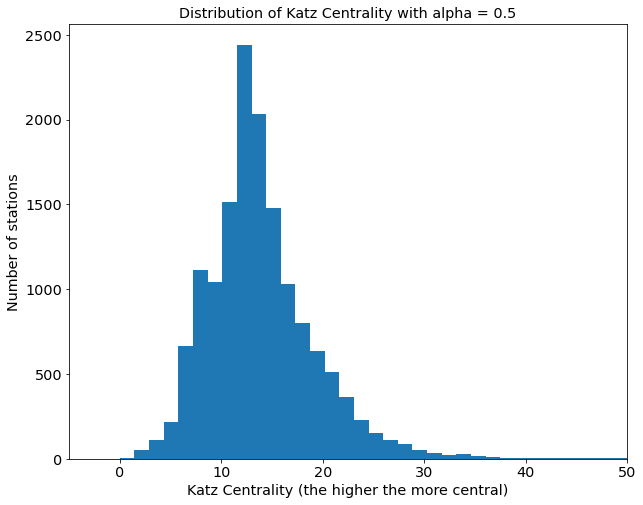

```python
katz = Katz(damping_factor=0.5)
scores = katz.fit_transform(adjacency)
plt.figure(figsize=(10,8))
plt.hist(sorted(scores),bins=100)
plt.xlim(-5,50)
plt.ylabel('Number of stations')
plt.xlabel('Katz Centrality (the higher the more central)')
plt.title('Distribution of Katz Centrality with alpha = 0.5')
plt.show;
```

### CLUSTERING DU RESEAU ROUTIER AVEC LOUVAIN AGGREGATE

```python
louvain = Louvain()

labels = louvain.fit_transform(adjacency)
labels_unique, counts = np.unique(labels, return_counts=True)
image = svg_graph(adjacency, position, labels=labels,node_size=6,height=700,width=700)

adjacency_aggregate = louvain.adjacency_
average = normalize(membership_matrix(labels).T)
position_aggregate = average.dot(position)
labels_unique, counts = np.unique(labels, return_counts=True)
image = svg_graph(adjacency_aggregate, position_aggregate, counts, labels=labels_unique,
                  display_node_weight=True, node_weights=counts, scale=0.5,node_size=4,height=1500,width=1500)
SVG(image)
```

[figure not shown]

```python
##**Degres centrality**

print("Top 10 Degree centrality road nodes: ")
centrality = nx.degree_centrality(Groad)
sorted(centrality.items(), reverse= True, key=lambda x: x[1])[:10]
```

```
Top 10 Degree centrality road nodes:
```

```
[('5453b63455474a33623195f2', 0.0016209644738619479),
 ('5453b63455474a3362318780', 0.0010806429825746318),
 ('5453b63455474a3362317b46', 0.0009455626097528029),
 ('5453b63455474a33623184ba', 0.0009455626097528029),
 ('5453b63455474a336231916c', 0.0009455626097528029),
 ('5453b63455474a33623191c3', 0.0009455626097528029),
 ('5453b63455474a33623199eb', 0.0009455626097528029),
 ('5453b63555474a336231a0be', 0.0009455626097528029),
 ('5453b63555474a336231a1ab', 0.0009455626097528029),
 ('5453b63555474a336231a2db', 0.0009455626097528029)]
```